# Analyzing the Effect of Extreme Weather Effects on Public Health and Economics Using the NOAA Storm Database

Ryan Barley

Thursday, December 18, 2014

```r
## Install and load required libraries
if (!(require(ggplot2, quietly=T))) {
    install.packages('ggplot2')
}
library(ggplot2)
```

# Analyzing the Effect of Extreme Weather Effects on Public Health and Economics Using the NOAA Storm Database

## Loading and Processing the Raw Data

We first download and read in the U.S. National Oceanic and Atmospheric Administration’s(NOAA) storm database.

```r
dir.create("./data", showWarnings=FALSE)

if(!file.exists("./data/StormData.csv.bz2")){
    url = "http://d396qusza40orc.cloudfront.net/repdata%2Fdata%2FStormData.csv.bz2"
    download.file(url, destfile = "./data/StormData.csv.bz2", method = "auto")
}

con <- bzfile("./data/StormData.csv.bz2", "rt")
data <- read.csv(con)
close(con)
```

After reading in the data, we check the first few rows of the dataset.

```r
head(data)
```

```
##   STATE__           BGN_DATE BGN_TIME TIME_ZONE COUNTY COUNTYNAME STATE
## 1       1  4/18/1950 0:00:00     0130       CST     97     MOBILE    AL
## 2       1  4/18/1950 0:00:00     0145       CST      3    BALDWIN    AL
## 3       1  2/20/1951 0:00:00     1600       CST     57    FAYETTE    AL
## 4       1   6/8/1951 0:00:00     0900       CST     89    MADISON    AL
## 5       1 11/15/1951 0:00:00     1500       CST     43    CULLMAN    AL
## 6       1 11/15/1951 0:00:00     2000       CST     77 LAUDERDALE    AL
##    EVTYPE BGN_RANGE BGN_AZI BGN_LOCATI END_DATE END_TIME COUNTY_END
## 1 TORNADO         0                                               0
## 2 TORNADO         0                                               0
## 3 TORNADO         0                                               0
## 4 TORNADO         0                                               0
## 5 TORNADO         0                                               0
## 6 TORNADO         0                                               0
##   COUNTYENDN END_RANGE END_AZI END_LOCATI LENGTH WIDTH F MAG FATALITIES
```

[output cut: 20 more lines]

There is much more information in this dataset than we need to answer our questions. To make it more manageable, we will subset out all of the information having to do with damage to persons and property.

```r
data.subset <- subset(data, select = c("EVTYPE", "FATALITIES", "INJURIES",
                                       "PROPDMG", "PROPDMGEXP",
                                        "CROPDMG", "CROPDMGEXP"))
```

First we will look at how harmful different storm events are to the population. looking at the levels of the variable EVTYPE, we see there is a lot of redundancy.

```r
x <- levels(factor((data.subset$EVTYPE)))
length(x)
```

```
## [1] 985
```

```r
head(levels(factor(data.subset$EVTYPE)))
```

```
## [1] "   HIGH SURF ADVISORY" " COASTAL FLOOD"        " FLASH FLOOD"
## [4] " LIGHTNING"            " TSTM WIND"            " TSTM WIND (G45)"
```

To fix this, we will try to sort as many of these events as we can into super-classes. The rest will be cleaned up in a moment.

```r
data.subset$EVTYPE <- toupper(data.subset$EVTYPE)
## Trim leading and trailing space using regex
trim <- function (x) gsub("^\\s+|\\s+$", "", x)
data.subset$EVTYPE <- trim(data.subset$EVTYPE)

data.subset$EVTYPE[grepl("FLOOD", data.subset$EVTYPE)] <- "FLOOD"
data.subset$EVTYPE[grepl("STREAM", data.subset$EVTYPE)] <- "FLOOD"
data.subset$EVTYPE[grepl("RISING", data.subset$EVTYPE)] <- "FLOOD"
data.subset$EVTYPE[grepl("URBAN", data.subset$EVTYPE)] <- "FLOOD"
data.subset$EVTYPE[grepl("COLD", data.subset$EVTYPE)] <- "COLD/WIND CHILL"
data.subset$EVTYPE[grepl("THERMIA", data.subset$EVTYPE)] <- "COLD/WIND CHILL"
data.subset$EVTYPE[grepl("HEAT", data.subset$EVTYPE)] <- "HEAT"
data.subset$EVTYPE[grepl("WARM", data.subset$EVTYPE)] <- "HEAT"
data.subset$EVTYPE[grepl("HAIL", data.subset$EVTYPE)] <- "HAIL"
data.subset$EVTYPE[grepl("SNOW", data.subset$EVTYPE)] <- "WINTER WEATHER"
data.subset$EVTYPE[grepl("BLIZZARD", data.subset$EVTYPE)] <- "BLIZZARD"
data.subset$EVTYPE[grepl("WINT", data.subset$EVTYPE)] <- "WINTER WEATHER"
data.subset$EVTYPE[grepl("FREEZING", data.subset$EVTYPE)] <- "WINTER WEATHER"
data.subset$EVTYPE[grepl("FREEZE", data.subset$EVTYPE)] <- "FROST/FREEZE"
data.subset$EVTYPE[grepl("FROST", data.subset$EVTYPE)] <- "FROST/FREEZE"
data.subset$EVTYPE[grepl("ICE", data.subset$EVTYPE)] <- "WINTER WEATHER"
data.subset$EVTYPE[grepl("ICY", data.subset$EVTYPE)] <- "WINTER WEATHER"
data.subset$EVTYPE[grepl("MIX", data.subset$EVTYPE)] <- "WINTER WEATHER"
data.subset$EVTYPE[grepl("VOLCANIC", data.subset$EVTYPE)] <- "VOLCANIC ASH"
data.subset$EVTYPE[grepl("WIND", data.subset$EVTYPE)] <- "WIND"
data.subset$EVTYPE[grepl("WND", data.subset$EVTYPE)] <- "WIND"
data.subset$EVTYPE[grepl("WET", data.subset$EVTYPE)] <- "RAIN"
data.subset$EVTYPE[grepl("RAIN", data.subset$EVTYPE)] <- "RAIN"
data.subset$EVTYPE[grepl("DRY", data.subset$EVTYPE)] <- "DROUGHT"
data.subset$EVTYPE[grepl("RECORD", data.subset$EVTYPE)] <- "EXTREME TEMPERATURE"
data.subset$EVTYPE[grepl("UNSEASONABLE", data.subset$EVTYPE)] <- "EXTREME TEMPERATURE"
data.subset$EVTYPE[grepl("EXCESSIVE", data.subset$EVTYPE)] <- "UNUSUAL WEATHER"
data.subset$EVTYPE[grepl("UNUSUAL", data.subset$EVTYPE)] <- "UNUSUAL WEATHER"
data.subset$EVTYPE[grepl("THUNDERSTORM", data.subset$EVTYPE)] <- "THUNDERSTORM"
data.subset$EVTYPE[grepl("TSTM", data.subset$EVTYPE)] <- "THUNDERSTORM"
data.subset$EVTYPE[grepl("TORN", data.subset$EVTYPE)] <- "TORNADO"
data.subset$EVTYPE[grepl("FUNNEL", data.subset$EVTYPE)] <- "TORNADO"
data.subset$EVTYPE[grepl("NADO", data.subset$EVTYPE)] <- "TORNADO"
data.subset$EVTYPE[grepl("WALL", data.subset$EVTYPE)] <- "TORNADO"
data.subset$EVTYPE[grepl("FIRE", data.subset$EVTYPE)] <- "WILDFIRE"
data.subset$EVTYPE[grepl("HURRICANE", data.subset$EVTYPE)] <- "HURRICANE"
data.subset$EVTYPE[grepl("TROPICAL", data.subset$EVTYPE)] <- "HURRICANE"
data.subset$EVTYPE[grepl("COASTAL", data.subset$EVTYPE)] <- "HURRICANE"
data.subset$EVTYPE[grepl("TYPHOON", data.subset$EVTYPE)] <- "HURRICANE"
data.subset$EVTYPE[grepl("CURRENT", data.subset$EVTYPE)] <- "RIP CURRENT"
data.subset$EVTYPE[grepl("SURF", data.subset$EVTYPE)] <- "HIGH SURF"
data.subset$EVTYPE[grepl("SWELL", data.subset$EVTYPE)] <- "HIGH SURF"
data.subset$EVTYPE[grepl("WAVE", data.subset$EVTYPE)] <- "HIGH SURF"
data.subset$EVTYPE[grepl("DUST", data.subset$EVTYPE)] <- "DUST"
data.subset$EVTYPE[grepl("LAND", data.subset$EVTYPE)] <- "DEBRIS FLOW"
data.subset$EVTYPE[grepl("EROS", data.subset$EVTYPE)] <- "DEBRIS FLOW"
data.subset$EVTYPE[grepl("ROCK", data.subset$EVTYPE)] <- "DEBRIS FLOW"
data.subset$EVTYPE[grepl("MUD", data.subset$EVTYPE)] <- "DEBRIS FLOW"
data.subset$EVTYPE[grepl("LIG", data.subset$EVTYPE)] <- "DEBRIS FLOW"
data.subset$EVTYPE[grepl("SPOUT", data.subset$EVTYPE)] <- "WATERSPOUT"
data.subset$EVTYPE[grepl("DEVIL", data.subset$EVTYPE)] <- "DUSTDEVIL"
data.subset$EVTYPE[grepl("DUST ", data.subset$EVTYPE)] <- "DUST STORM"
data.subset$EVTYPE[grepl("AVALAN", data.subset$EVTYPE)] <- "AVALANCHE"
data.subset$EVTYPE[grepl("SEAS", data.subset$EVTYPE)] <- "HEAVY SEAS"
data.subset$EVTYPE[grepl("FOG", data.subset$EVTYPE)] <- "FOG"
```

To ascertain how harmful different storms are to the population, we will define how harmful a storm event was by looking at the total number of people injured and killed. To do this, we will first create a new variable called HARMED, which sums the number of people injured and killed for each event.

```r
data.subset$HARMED <- (data.subset$INJURIES + data.subset$FATALITIES)
```

We are only interested in storm events that were harmful to the population. If a storm event caused no harm to any person, then we can remove it from the dataset.

```r
## Remove Events that do not contribute to overall population harm
elim <- !(grepl(0, data.subset$HARMED))
data.subset <- data.subset[elim==T,]

levels(factor(data.subset$EVTYPE))
```

```
##  [1] "AVALANCHE"        "BLIZZARD"         "DEBRIS FLOW"
##  [4] "DROUGHT"          "DROWNING"         "DUST"
##  [7] "FLOOD"            "FOG"              "FROST/FREEZE"
## [10] "GLAZE"            "HAIL"             "HEAT"
## [13] "HEAVY SEAS"       "HIGH"             "HIGH SURF"
## [16] "HIGH WATER"       "HURRICANE"        "LOW TEMPERATURE"
## [19] "MARINE ACCIDENT"  "MARINE MISHAP"    "OTHER"
## [22] "RAIN"             "RIP CURRENT"      "SLEET"
## [25] "STORM SURGE"      "STORM SURGE/TIDE" "THUNDERSTORM"
## [28] "TORNADO"          "TSUNAMI"          "WATERSPOUT"
## [31] "WILDFIRE"         "WIND"             "WINTER WEATHER"
```

We have successfully narrowed down the number of different storm events around 30. This is fewer than the number in the NOAA code book, but that is okay for our purposes.

Next, we will aggregate the number of people harmed with the type of storm event to see the total number of people harmed by each event.

```r
harmed.total <- aggregate(HARMED ~ EVTYPE, data.subset, sum)
```

Now that we have finished processing the data looking at how harmful these storm events are for people, we can start focusing on our second question: how harmful these events are for the economy.

```r
data.subset$PROPDMGEXP <- toupper(data.subset$PROPDMGEXP)
data.subset$CROPDMGEXP <- toupper(data.subset$CROPDMGEXP)

## Replace factor levels that have been lost in subsetting
data.subset$PROPDMGEXP <- as.character(data.subset$PROPDMGEXP)
data.subset$CROPDMGEXP <- as.character(data.subset$CROPDMGEXP)

levels(factor(data.subset$PROPDMGEXP)) # [1] ""  "-" "0" "5" "7" "B" "H" "K" "M"
```

```
## [1] ""  "-" "0" "5" "7" "B" "H" "K" "M"
```

```r
levels(data.subset$CROPDMGEXP) # [1] ""  "0" "B" "K" "M"
```

Looking at this data, we can see that it needs a little bit of cleaning, too. The NOAA code book says that the proper entries for the damage exponent column are “B” for billion, “M” for million, and “K” for thousand. For the purpose of this assessment, everything else can be ignored. We will set those values to 1.

```r
data.subset$PROPDMGEXP[grepl("-|0|5|7|H", data.subset$PROPDMGEXP)] <- "1"
data.subset$PROPDMGEXP[grepl("K", data.subset$PROPDMGEXP)] <- "1000"
data.subset$PROPDMGEXP[grepl("M", data.subset$PROPDMGEXP)] <- "1000000"
data.subset$PROPDMGEXP[grepl('B', data.subset$PROPDMGEXP)] <- "1000000000"


data.subset$CROPDMGEXP[grepl("B", data.subset$CROPDMGEXP)] <- "1000000000"
data.subset$CROPDMGEXP[grepl("K", data.subset$CROPDMGEXP)] <- "1000"
data.subset$CROPDMGEXP[grepl("M", data.subset$CROPDMGEXP)] <- "1000000"

data.subset$PROPDMG <- as.numeric(data.subset$PROPDMG)
data.subset$CROPDMG <- as.numeric(data.subset$CROPDMG)

data.subset$PROPDMGEXP <- as.numeric(data.subset$PROPDMGEXP)
data.subset$CROPDMGEXP <- as.numeric(data.subset$CROPDMGEXP)
```

Once these multipliers are in place, we will multiply the damage column by the damage exponent columns for both the property and crop values, and aggregate the sum of each.

```r
data.subset$TOTALPROP <- data.subset$PROPDMG * data.subset$PROPDMGEXP
data.subset$TOTALCROP <- data.subset$CROPDMG * data.subset$CROPDMGEXP

prop.total <- aggregate(TOTALPROP ~ EVTYPE, data.subset, sum)
crop.total <- aggregate(TOTALCROP ~ EVTYPE, data.subset, sum)
```

# Results

We are now ready to review our data, and answer our original questions.

## 1. What kinds of storm events are the most harmful to the populations health?

To answer this question, we will return to our definition of harm being the sum of injuries and fatalities. Plotting all 33 events on one graph is cumbersome, so for our analysis we chose to limit the number of events we are plotting to the top 10 most harmful. We will rank them by most people harmed, and then subset the top 10 results.

```r
harmed.df <- harmed.total[order(harmed.total$HARMED, decreasing = T), ][1:10, ]
levels(harmed.df$EVTYPE) <- as.character.factor(harmed.df$EVTYPE)
## This will allow us to sort by factors
harmed.df$EVTYPE <- factor(harmed.df$EVTYPE, as.character(harmed.df$EVTYPE))
harmed.df
```

```
##            EVTYPE HARMED
## 28        TORNADO  77153
## 32           WIND  12178
## 12           HEAT  10219
## 3     DEBRIS FLOW   6027
## 33 WINTER WEATHER   5228
## 7           FLOOD   4333
## 17      HURRICANE   1700
## 31       WILDFIRE   1504
## 11           HAIL   1173
## 23    RIP CURRENT   1086
```

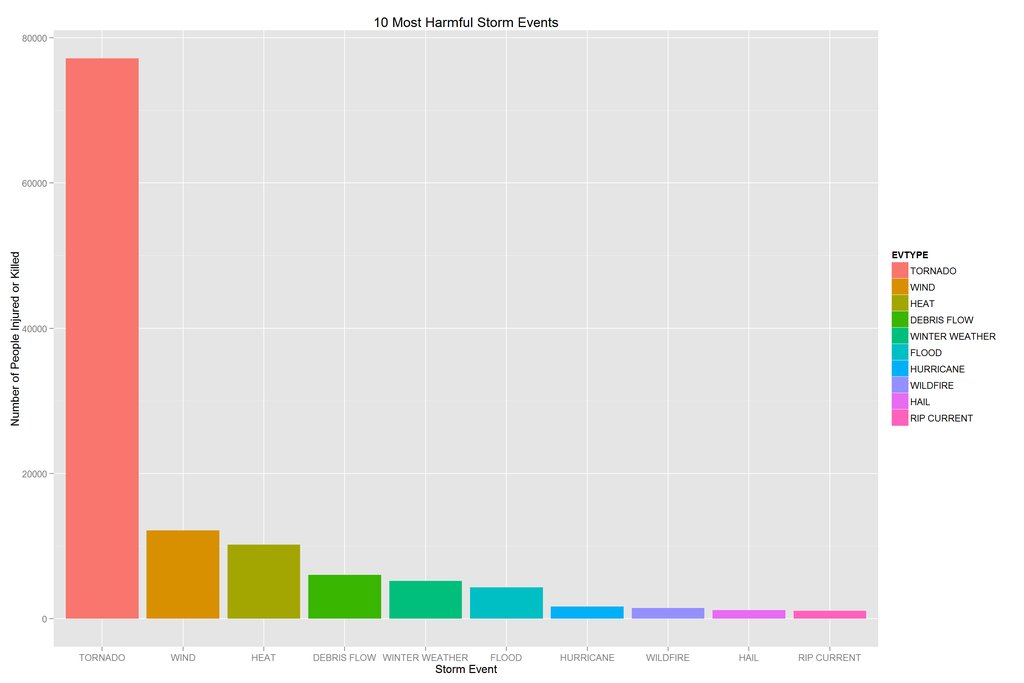

```r
g <- ggplot(harmed.df, aes(y = HARMED))
g <- g + geom_bar(aes(x = EVTYPE, fill = EVTYPE), data = harmed.df, stat="identity")
g <- g + labs(title = "10 Most Harmful Storm Events",
              x = "Storm Event",
              y = "Number of People Injured or Killed")
g
```

## Question 2: Across the United States, which types of events have the greatest economic consequences?

For this question, we are dividing our answer up into two parts: what storm event caused the most costly damage to property, and which did the most costly damage to crops. Again, we will be looking at the top 10 results

```r
prop.df <- prop.total[order(prop.total$TOTALPROP, decreasing = T), ][1:10, ]
## Numbers are very large, so we will divide the totals by 1000 to normalize
prop.df$TOTALPROP <- prop.df$TOTALPROP / 1000
prop.df$EVTYPE <- factor(prop.df$EVTYPE, as.character(prop.df$EVTYPE))
prop.df
```

```
##              EVTYPE TOTALPROP
## 14        HURRICANE  44194396
## 21          TORNADO  32219178
## 6             FLOOD   8538895
## 26   WINTER WEATHER   6280072
## 25             WIND   5668501
## 10             HAIL   4909853
## 19 STORM SURGE/TIDE   4004000
## 24         WILDFIRE   3504977
## 2          BLIZZARD    463786
## 22          TSUNAMI     84000
```

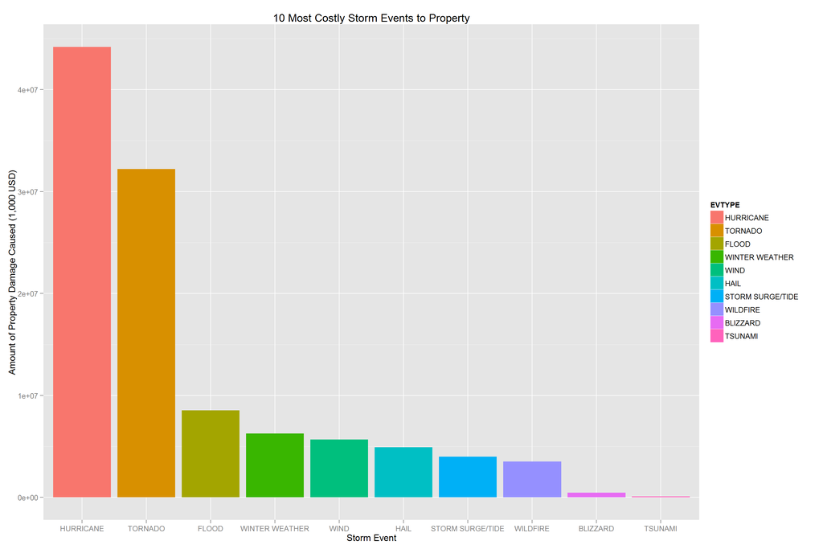

```r
p <- ggplot(prop.df, aes(y = TOTALPROP))
p <- p + geom_bar(aes(x = EVTYPE, fill = EVTYPE), data = prop.df, stat="identity")
p <- p + labs(title = "10 Most Costly Storm Events to Property",
              x = "Storm Event",
              y = "Amount of Property Damage Caused (1,000 USD)")
p
```

```r
crop.df <- crop.total[order(crop.total$TOTALCROP, decreasing = T), ][1:10, ]
## Values are very large, so we will divide the totals by 1 million
crop.df$TOTALCROP <- crop.df$TOTALCROP / 1000000
crop.df$EVTYPE <- factor(crop.df$EVTYPE, as.character(crop.df$EVTYPE))
crop.df
```

```
##            EVTYPE TOTALCROP
## 12      HURRICANE 3972.9258
## 19           WIND  621.4417
## 10           HEAT  493.9000
## 6           FLOOD  204.4313
## 9            HAIL  165.6200
## 16        TORNADO  130.0870
## 18       WILDFIRE  114.7270
## 2        BLIZZARD   62.0500
## 8    FROST/FREEZE   50.0000
## 20 WINTER WEATHER   35.9930
```

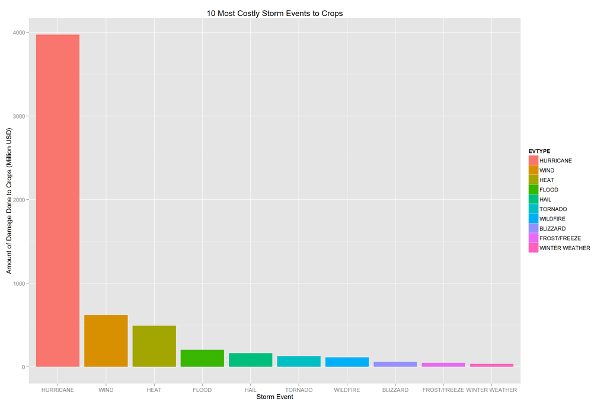

```r
q <- ggplot(crop.df, aes(y = TOTALCROP))
q <- q + geom_bar(aes(x = EVTYPE, fill = EVTYPE), data = crop.df, stat="identity")
q <- q + labs(title = "10 Most Costly Storm Events to Crops",
              x = "Storm Event",
              y = "Amount of Damage Done to Crops (Million USD)")
q
```